# Plotting thematic Swiss maps with RSwissMaps

David Zumbach

2017-10-09

## Introduction

RSwissMaps allows to link thematic data to Swiss administrative divisions (municipalities, districts, cantons) and to plot it on a map. The maps can be customised to some degree and saved in different formats and resolutions. The installed GitHub version of the package comes with all available geodata pre-installed. The package also allows to generate tailored templates for data collection. The geodata used is publicly available on the [Swiss Federal Statistical Office website](https://www.bfs.admin.ch/bfs/de/home/dienstleistungen/geostat/geodaten-bundesstatistik.html).

### Data availability

Geodata of Swiss municipalities, districts, and cantons is currently available for the following reference dates: 2001-1-1, 2002-1-1, 2003-1-1, 2004-1-1, 2005-1-1, 2006-1-1, 2007-1-1, 2008-1-1, 2009-1-1, 2010-1-1, 2010-31-12, 2011-1-1, 2011-31-12, 2012-1-1, 2012-31-12, 2013-1-1, 2013-31-12, 2014-1-1, 2014-31-12, 2015-1-1, 2015-31-12, 2016-1-1, 2016-31-12, 2017-1-1.

### Coordinate reference system

CH1903/LV03 (EPSG:21781). For more information, please see: [swisstopo](https://www.swisstopo.admin.ch/en/knowledge-facts/surveying-geodesy/reference-systems/switzerland.html) and [Spatial Reference](http://spatialreference.org/ref/epsg/21781/)

### Commercial use

For commercial use of the data, see: [GEOSTAT, BFS](https://www.bfs.admin.ch/bfs/de/home/dienstleistungen/geostat/nutzungsbedingungen.html)

## Installation

### GitHub version

For regularly updated version with all geodata pre-installed, install from *GitHub*:

```r
install.packages("devtools")
devtools::install_github("zumbov2/RSwissMaps", subdir = "allinone")
```

### CRAN version

The version 0.1.0 is on CRAN, and you can install it by:

```r
install.packages("RSwissMaps")
```

## Plotting thematic municipality-level maps

```r
library(RSwissMaps)
```

### Data collection (random data)

```r
dt <- mun.template(2016)
for(i in 1:nrow(dt)){dt$values[i] <- sample(c(400:650), 1)/1000}
```

### Plotting map of sample data

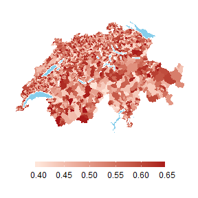

```r
mun.plot(dt$bfs_nr, dt$values, 2016,
         boundaries = "") # boundaries are switched off due to poor resolution
```

### Plotting a tailor-made map of sample data

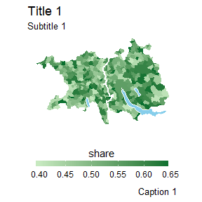

```r
mun.plot(dt$bfs_nr, dt$values, 2016,
         cantons = c("AG", "ZH"), # cantons of Aargau and Zurich
         lakes = c(9040, 9050, 9172), # corresponding lake IDs
         boundaries = "c", # display canton boundaries
         boundaries_size = 1,
         color_continuous = c("#c7e9c0", "#006d2c"), # some green
         title = "Title 1",
         subtitle = "Subtitle 1",
         caption = "Caption 1",
         legend_title = "share")
```

## Plotting thematic district-level maps

### Data collection (random data)

```r
dt2 <- dis.template(2016)
for(i in 1:nrow(dt2)){dt2$values[i] <- sample(c(200:400), 1)/1000}
```

### Plotting map of sample data

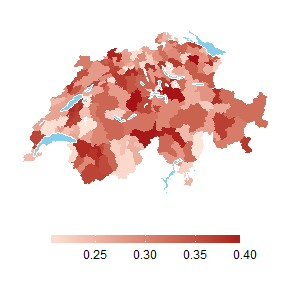

```r
dis.plot(dt2$bfs_nr, dt2$values, 2016,
         boundaries = "") # boundaries are switched off due to poor resolution
```

### Plotting a tailor-made map of sample data

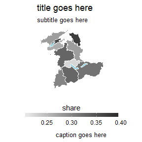

```r
dis.plot(dt2$bfs_nr, dt2$values, 2016,
         cantons = c("BE"), # canton of Bern
         lakes = c("Bielersee", "Brienzersee", "Thunersee"), # corresponding lakes
         color_continuous = c("#f0f0f0", "#252525"), # black/white
         title = "title goes here",
         subtitle = "subtitle goes here",
         caption = "caption goes here",
         legend_title = "share")
```

## Plotting thematic canton-level maps

### Data collection (random data)

```r
dt3 <- can.template(2016)
for(i in 1:nrow(dt3)){dt3$values[i] <- sample(c(450:700), 1)/1000}
```

### Plotting map of sample data

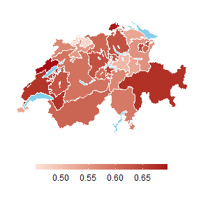

```r
can.plot(dt3$bfs_nr, dt3$values, 2016)
```

### Plotting a tailor-made map of sample data

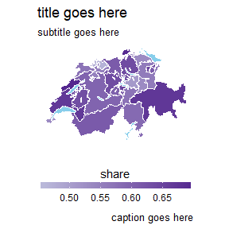

```r
can.plot(dt3$bfs_nr, dt3$values, 2016,
         color_continuous = c("#bcbddc", "#54278f"), # purple
         title = "title goes here",
         subtitle = "subtitle goes here",
         caption = "caption goes here",
         legend_title = "share")
```